# Carbon fixation and belowground allocation

Hannah L. Hubanks

2018-1-30

# Photosynthesis, our solar energy converter

Carbon in the air is magically placed into the soil by tiny brilliant elves. Just kidding. But sort of- it’s a very complex process of interactions between microbial life and plants that we have to thank for this crucial step in the carbon cycle, a [benefit](https://powellcenter-soilcarbon.github.io/SOC-Hub/global-context/2017/05/04/Dynamic-role/) to the system.

Three different metabolic pathways exist for carbon dioxide fixation in plants which also categorizes plants into groups: C3, C4, and CAM. High temperatures and dry weather favor C4 and CAM plants, which are adapted to these areas to increase photosynthetic efficiency. Photosynthetic capacity is also variable through the course of plant development and among species. While respiration and carbon uptake through photosynthesis is only the first step to carbon being stored in the soil, its important to acknowledge that these factors play a role in carbon fixed from the atmosphere and how carbon fixation in climates with increasing temperatures may be impacted.

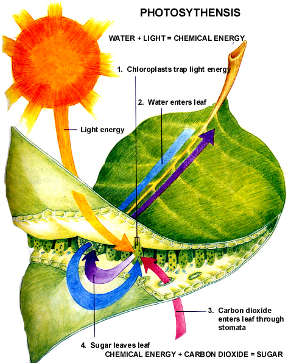

Figure 1. Photosynthesis within the leaf of a plant, producing energy in the form of sugar. View this image [here](http://gleeson11biology.pbworks.com/f/1223346423/photosynthesis%20summary.jpg)

References:

Larcher, W., 1995. Physiological plant ecology: ecophysiology and stress physiology of functional groups. Springer-Verlag. DOI: 10.1016/S0016-7061(96)00036-5

# Carbon use within plants

Once carbohydrates are created within the plant, they are used as the physical plant building blocks (organic matter) and generate the energy for plant growth. Carbon from the atmosphere becomes the structural components of vegetation, including above and below ground plant mass. Where carbon is allocated within the plant can be impacted by environmental conditions such as heat and drought. In the tundra, where large amounts of the world’s soil carbon is stored, increased temperatures may shift plant carbon allocation above ground.

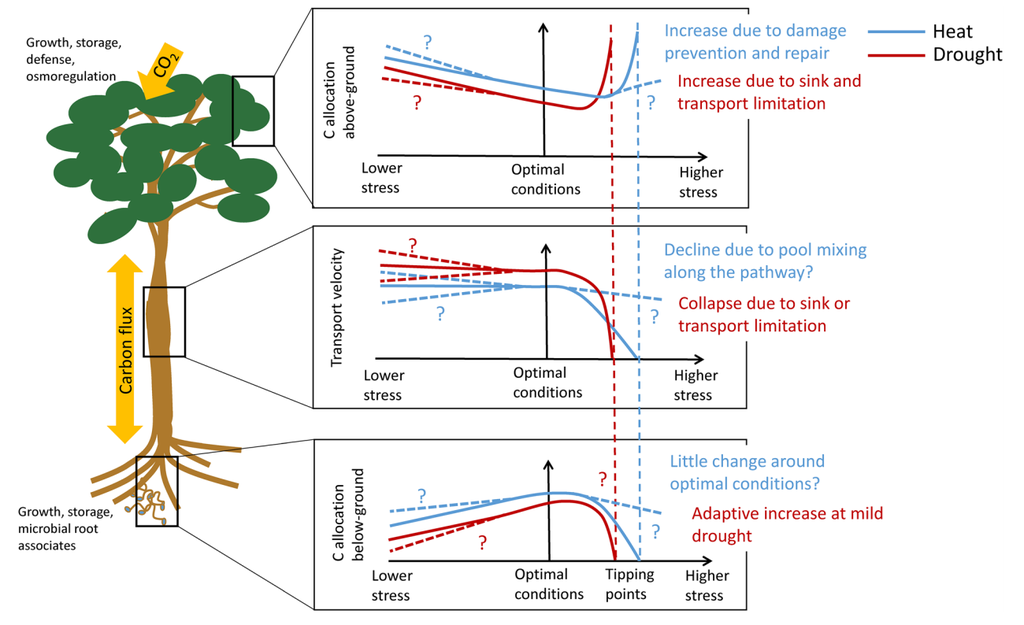

Figure 2. Heat and drought affect a plant’s carbon allocation, and change depending on the stress condition of the plant. Under stress, heat and drought can shift plant carbon allocation above ground. View this image [here](https://academic.oup.com/treephys/article/35/6/581/1646587) from Sevanto and Dickman, 2015.

References:

Sevanto, S., Dickman, L.T., 2015. Where does the carbon go?–Plant carbon allocation under climate change. Tree Physiology 35, 581–584. DOI: [10.1093/treephys/tpv059](https://academic.oup.com/treephys/article/35/6/581/1646587)

Wang, P., Heijmans, M.M.P.D., Mommer, L., van Ruijven, J., Maximov, T.C., Berendse, F., 2016. Belowground plant biomass allocation in tundra ecosystems and its relationship with temperature. Environmental Research Letters 11, 055003. DOI: [10.1088/1748-9326/11/5/055003](http://iopscience.iop.org/article/10.1088/1748-9326/11/5/055003/pdf)

# Interactions of carbon with soil environment

Carbon enters the soil from plants, and the resulting soil organic matter cycles into the soil profile by multiple processes. To enter the soil, carbon can leave the plant as root exudates or as plant litter, further decomposed by microorganisms. A large portion of a plant’s photosynthetically fixed carbon enters the soil through root exudates, which consist of organic compounds and enzymes that protect and support the plant within the diverse microorganism community living in the rhizosphere.

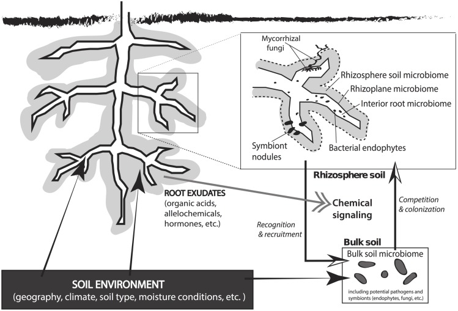

Figure 3. Interactions of root exuates with the rhizosphere which funtion to attract beneficial microbes and deter pathogenic microbes. View this image [here](https://www.researchgate.net/publication/264642727_The_rhizosphere_microbiota_of_plant_invaders_An_overview_of_recent_advances_in_the_microbiomics_of_invasive_plants) from Coats and Rumpho, 2014. DOI: [10.3389/fmicb.2014.00368](https://www.researchgate.net/publication/264642727_The_rhizosphere_microbiota_of_plant_invaders_An_overview_of_recent_advances_in_the_microbiomics_of_invasive_plants)

Plant litter is decomposed by a host of soil fungi and bacteria into microbial products and biomass. Once in the soil, carbon cycles by physical mixing via decomposers such as earthworms and microorganisms, mineral-organo associations, and by freeze/thaw cycles within certain climates.

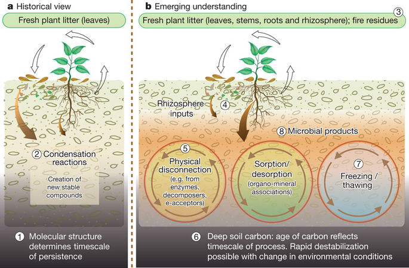

Figure 4. An emerging understanding of how carbon enters the soil from plant matter and exudates, and how it is incorporated into the soil profile. View this image [here](https://media.springernature.com/m685/nature-assets/nature/journal/v478/n7367/images/nature10386-f3.2.jpg) from Schmidt et al., 2011. DOI: [10.1038/nature10386](https://www.nature.com/articles/nature10386)

References:

Marschner H (1995) Mineral Nutrition of Higher Plants (Academic Press, London), Ed 2.

Schmidt, M.W.I., Torn, M.S., Abiven, S., Dittmar, T., Guggenberger, G., Janssens, I.A., Kleber, M., Kögel-Knabner, I., Lehmann, J., Manning, D.A.C., Nannipieri, P., Rasse, D.P., Weiner, S., Trumbore, S.E., 2011. Persistence of soil organic matter as an ecosystem property. Nature 478, 49–56. DOI: [10.1038/nature10386](https://www.nature.com/articles/nature10386)

Walker, T.S., 2003. Root Exudation and Rhizosphere Biology. PLANT PHYSIOLOGY 132, 44–51. DOI: [10.1104/pp.102.019661](http://www.plantphysiol.org/content/132/1/44)

# Carbon sources for carbon sequestration

Vegetation type, management, and biomass location (above ground or below ground biomass) can vary the amount of plant biomass carbon retained in the soil organic matter (SOM). In Figure 5, we see that soybeans, for example, show a high ratio of below ground to above ground carbon inputs retained in the SOM, as well as organic agriculture practices. The dominance of belowground carbon being retained in the SOM shows the importance of root sourced carbon in long term carbon stabilization.

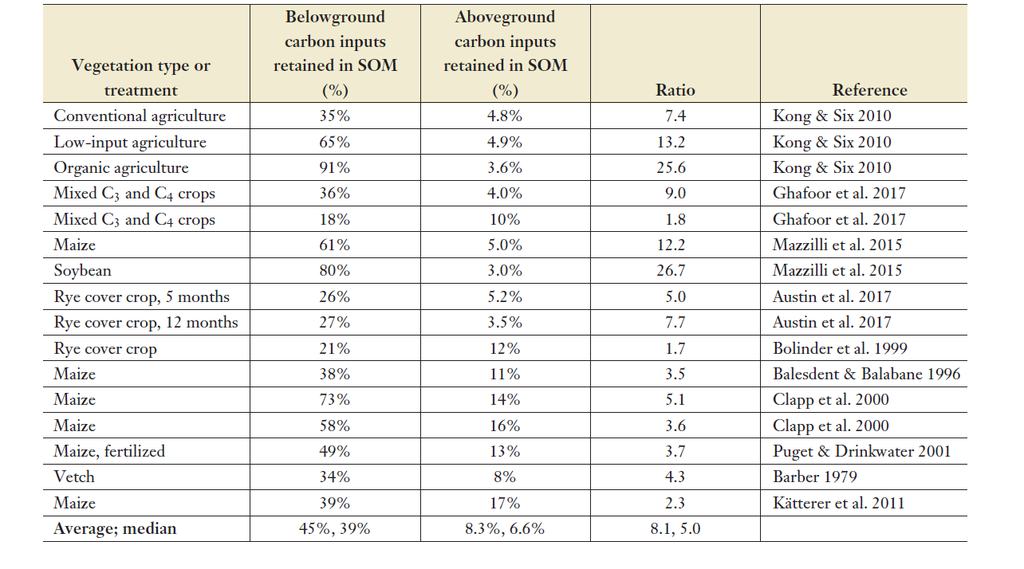

Figure 5. The source of carbon inputs retained in soil organic matter. View image [here](https://jacksonlab.stanford.edu/sites/default/files/jackson_et_al._arees_2017.pdf) from Jackson et al., 2017.

References:

Jackson, R.B., Lajtha, K., Crow, S.E., Hugelius, G., Kramer, M.G., Piñeiro, G., 2017. The Ecology of Soil Carbon: Pools, Vulnerabilities, and Biotic and Abiotic Controls. Annual Review of Ecology, Evolution, and Systematics 48. DOI: [10.1146/annurev-ecolsys-112414-054234](https://jacksonlab.stanford.edu/sites/default/files/jackson_et_al._arees_2017.pdf)

# Soil organic matter formation and agroecosystems

SOM formation is crucial to the soil ecosystem, and is comprised of nearly 50% carbon. This soil organic carbon (SOC) is responsible for a whole host of soil health functions. Increased SOC has been linked to higher resistance to disease, erosion, nutrient retention, and supporting crucial microbial life. In order for the SOC to be stored long term, or sequestered, various supporting processes must break it down from its plant material while also being protected from release back to the atmosphere. Managed ecosystems often have reduced SOM in their systems due to increased disturbance such as soil compaction, whereas natural systems show higher SOM. Increasing SOM is a major goal for global soil health initiatives, to better reflect the ecosystem functions of a natural system within managed agroecosystems.

[figure not shown]

Figure 6. A visual representation of the relationship between soil organic matter, human impact and ecosystem processes. View image [here](https://jacksonlab.stanford.edu/sites/default/files/jackson_et_al._arees_2017.pdf) from Jackson et al., 2017.

References:

Jackson, R.B., Lajtha, K., Crow, S.E., Hugelius, G., Kramer, M.G., Piñeiro, G., 2017. The Ecology of Soil Carbon: Pools, Vulnerabilities, and Biotic and Abiotic Controls. Annual Review of Ecology, Evolution, and Systematics 48. DOI: [10.1146/annurev-ecolsys-112414-054234](https://jacksonlab.stanford.edu/sites/default/files/jackson_et_al._arees_2017.pdf)